# Taller 2: Regresion Lineal Multiple

Bioestadistica Fundamental

Andres Felipe Florez Rivera

2026-07-13

Universidad Nacional de Colombia — Departamento de Estadistica, Sede Bogota

Este taller tiene dos partes. La **Parte I** presenta las herramientas en R necesarias para realizar un analisis completo de regresion lineal multiple por MCO. La **Parte II** plantea el trabajo que los estudiantes deben entregar, aplicando todas las herramientas aprendidas a un nuevo conjunto de datos.

# Parte I: Herramientas en R para Regresion Lineal Multiple

Para ilustrar cada herramienta se usa un conjunto de datos simulado con contexto agronomico: contenido de cafeina del grano de cafe (mg/g) en funcion de tres factores medidos en 60 parcelas del Eje Cafetero. Los datos se generan de forma reproducible con `set.seed(42)`.

```r
set.seed(42)
n            <- 60
fertilizante <- round(runif(n, 80, 300), 1)
altitud      <- round(runif(n, 1200, 1900), 0)
densidad     <- round(runif(n, 4000, 8000), 0)
variedad     <- factor(sample(c("Castillo", "Colombia", "Cenicafe1"), n, replace = TRUE))

cafeina  <- round(
  15 + 0.025 * fertilizante - 0.003 * altitud + 0.001 * densidad +
  ifelse(variedad == "Colombia",  2.0, 0) +
  ifelse(variedad == "Cenicafe1", 1.5, 0) +
  rnorm(n, 0, 1.0), 2
)

datos <- data.frame(cafeina, fertilizante, altitud, densidad, variedad)

mostrar_tabla(datos, caption = "Cafeina y variables explicativas")
```

Cafeina y variables explicativas

| cafeina | fertilizante | altitud | densidad | variedad |
| --- | --- | --- | --- | --- |
| 24.62 | 281.3 | 1673 | 5427 | Colombia |
| 24.70 | 286.2 | 1888 | 5643 | Colombia |
| 21.18 | 143.0 | 1732 | 6294 | Colombia |
| 24.64 | 262.7 | 1597 | 6359 | Cenicafe1 |
| 25.15 | 221.2 | 1795 | 6879 | Colombia |
| 24.38 | 194.2 | 1333 | 5580 | Cenicafe1 |
| 25.46 | 242.0 | 1390 | 7677 | Colombia |
| 22.13 | 109.6 | 1780 | 7850 | Colombia |
| 23.19 | 224.5 | 1685 | 4934 | Cenicafe1 |
| 25.20 | 235.1 | 1368 | 6898 | Colombia |
| 25.39 | 180.7 | 1230 | 7615 | Colombia |
| 23.39 | 238.2 | 1298 | 6414 | Castillo |
| 23.73 | 285.6 | 1351 | 6526 | Castillo |
| 23.10 | 136.2 | 1536 | 7750 | Colombia |
| 24.90 | 181.7 | 1338 | 7402 | Colombia |

Las variables son:

| Variable | Tipo | Descripcion | Unidad / Categorias |
| --- | --- | --- | --- |
| `cafeina` | Cuantitativa | Contenido de cafeina del grano de cafe | mg/g |
| `fertilizante` | Cuantitativa | Dosis de fertilizante nitrogenado aplicada | kg N/ha |
| `altitud` | Cuantitativa | Altitud de la parcela sobre el nivel del mar | m.s.n.m. |
| `densidad` | Cuantitativa | Densidad de siembra | plantas/ha |
| `variedad` | Cualitativa | Variedad de cafe sembrada | Castillo / Colombia / Cenicafe1 |

## 1. Exploracion inicial de los datos

Antes de ajustar un modelo de regresion siempre se deben explorar los datos.

### 1.1 Estadisticas descriptivas

```r
summary(datos)
```

```
##     cafeina       fertilizante      altitud        densidad         variedad
##  Min.   :16.58   Min.   : 80.9   Min.   :1200   Min.   :4116   Castillo :18
##  1st Qu.:21.36   1st Qu.:161.7   1st Qu.:1352   1st Qu.:5244   Cenicafe1:16
##  Median :23.02   Median :215.3   Median :1575   Median :6306   Colombia :26
##  Mean   :22.87   Mean   :205.5   Mean   :1540   Mean   :6110
##  3rd Qu.:24.43   3rd Qu.:263.4   3rd Qu.:1713   3rd Qu.:7062
##  Max.   :28.66   Max.   :297.6   Max.   :1888   Max.   :7850
```

### 1.2 Matriz de correlaciones (variables cuantitativas)

La matriz de correlaciones solo aplica a variables cuantitativas. La variable `variedad` se excluye de este calculo.

```r
vars_num <- c("cafeina", "fertilizante", "altitud", "densidad")
mat_cor  <- round(cor(datos[, vars_num]), 4)
mostrar_tabla(as.data.frame(mat_cor), caption = "Matriz de correlaciones entre variables cuantitativas")
```

Matriz de correlaciones entre variables cuantitativas

|  | cafeina | fertilizante | altitud | densidad |
| --- | --- | --- | --- | --- |
| cafeina | 1.0000 | 0.5927 | -0.2062 | 0.5131 |
| fertilizante | 0.5927 | 1.0000 | -0.0096 | -0.1009 |
| altitud | -0.2062 | -0.0096 | 1.0000 | -0.0349 |
| densidad | 0.5131 | -0.1009 | -0.0349 | 1.0000 |

> Correlaciones altas entre $Y$ y los predictores indican que esas variables son buenos candidatos para el modelo. Correlaciones altas entre predictores ($|r| > 0.7$) son una primera senal de posible multicolinealidad.

### 1.3 Exploracion de la variable cualitativa

Para variables cualitativas se usan tablas de frecuencias y diagramas de caja.

```r
table(datos$variedad)
```

```
##
##  Castillo Cenicafe1  Colombia
##        18        16        26
```

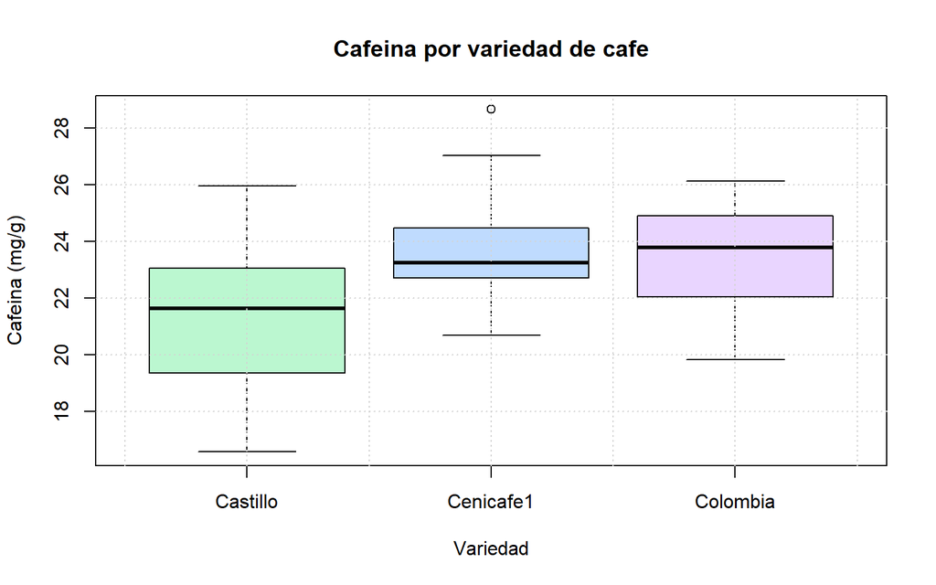

```r
boxplot(
  cafeina ~ variedad,
  data  = datos,
  col   = c("#bbf7d0", "#bfdbfe", "#e9d5ff"),
  xlab  = "Variedad",
  ylab  = "Cafeina (mg/g)",
  main  = "Cafeina por variedad de cafe"
)
grid()
```

> El diagrama de caja permite evaluar si las variedades tienen contenidos promedio de cafeina distintos, lo que justifica incluir la variable en el modelo.

### 1.4 Diagramas de dispersion por pares (cuantitativas)

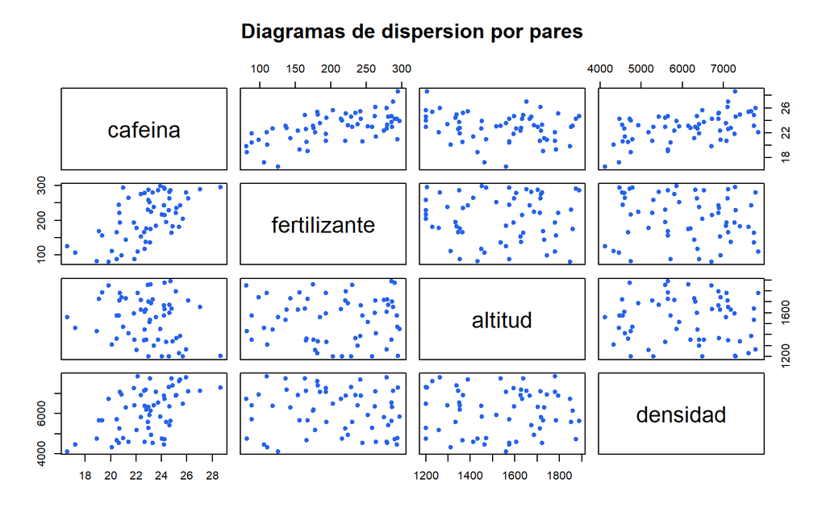

```r
pairs(
  datos[, vars_num],
  col  = "#2563eb",
  pch  = 19,
  cex  = 0.8,
  main = "Diagramas de dispersion por pares"
)
```

> Cada panel muestra la relacion entre dos variables cuantitativas.

## 2. El modelo de regresion lineal multiple

El modelo poblacional con $k$ predictores es:

$$Y_i = \beta_0 + \beta_1 X_{1i} + \beta_2
X_{2i} + \cdots + \beta_k X_{ki} + e_i, \quad e_i \sim N(0, \sigma^2),
\quad i = 1, \ldots, n$$

En notacion matricial compacta: $\mathbf{Y} = \mathbf{X}\boldsymbol{\beta} + \mathbf{e}$

| Componente | Significado |
| --- | --- |
| $Y_i$ | Valor observado de la variable respuesta |
| $X_{1i}, X_{2i}, \ldots, X_{ki}$ | Valores de los $k$ predictores para la observacion $i$ |
| $\beta_0$ | Intercepto: valor esperado de $Y$ cuando todos los predictores valen cero |
| $\beta_1, \ldots, \beta_k$ | Efecto parcial de cada predictor sobre $Y$, manteniendo los demas constantes |
| $e_i$ | Error aleatorio asociado a la observacion $i$ |

En este ejemplo con tres variables cuantitativas y una cualitativa con tres categorias (“Castillo” es la categoria de referencia):

$$Y_i = \beta_0 + \beta_1
\text{Fertilizante}_i + \beta_2 \text{Altitud}_i + \beta_3
\text{Densidad}_i + \beta_4 D_{\text{Colombia},i} + \beta_5
D_{\text{Cenicafe1},i} + e_i$$

Donde $D_{\text{Colombia}}$ y $D_{\text{Cenicafe1}}$ son **variables indicadoras** (dummy) que valen 1 si la parcela pertenece a esa variedad y 0 en caso contrario. R las crea automaticamente al incluir un `factor` en `lm()`.

> **Categoria de referencia:** cuando $D_{\text{Colombia}} = 0$ y $D_{\text{Cenicafe1}} = 0$, la observacion pertenece a la variedad “Castillo”. Los coeficientes $\beta_4$ y $\beta_5$ miden la diferencia en contenido de cafeina respecto a “Castillo”, manteniendo los demas predictores constantes.

## 3. Estimacion por Minimos Cuadrados Ordinarios (MCO)

En regresion multiple, MCO minimiza la suma de cuadrados de los residuos:

$$S(\boldsymbol{\beta}) = \sum_{i=1}^{n}
e_i^2 = \|\mathbf{Y} - \mathbf{X}\boldsymbol{\beta}\|^2$$

La solucion matricial es:

$$\hat{\boldsymbol{\beta}} =
(\mathbf{X}^\top\mathbf{X})^{-1}\mathbf{X}^\top\mathbf{Y}$$

Esta es la expresion que R resuelve internamente con `lm()`.

### 3.1 Ajuste del modelo con `lm()`

```r
modelo <- lm(cafeina ~ fertilizante + altitud + densidad + variedad, data = datos)
summary(modelo)
```

```
##
## Call:
## lm(formula = cafeina ~ fertilizante + altitud + densidad + variedad,
##     data = datos)
##
## Residuals:
##      Min       1Q   Median       3Q      Max
## -1.78242 -0.48850  0.02108  0.53706  1.69421
##
## Coefficients:
##                     Estimate Std. Error t value Pr(>|t|)
## (Intercept)       13.5724700  1.1029154  12.306  < 2e-16 ***
## fertilizante       0.0244210  0.0016547  14.759  < 2e-16 ***
## altitud           -0.0022513  0.0005246  -4.291 7.41e-05 ***
## densidad           0.0010286  0.0001006  10.221 3.13e-14 ***
## variedadCenicafe1  1.9558262  0.2833819   6.902 5.95e-09 ***
## variedadColombia   2.1779953  0.2611735   8.339 2.81e-11 ***
## ---
## Signif. codes:  0 '***' 0.001 '**' 0.01 '*' 0.05 '.' 0.1 ' ' 1
##
## Residual standard error: 0.8165 on 54 degrees of freedom
## Multiple R-squared:  0.8836, Adjusted R-squared:  0.8729
## F-statistic: 82.01 on 5 and 54 DF,  p-value: < 2.2e-16
```

### 3.2 Extraccion de los coeficientes estimados

```r
coefs <- coef(modelo)
for (nm in names(coefs)) {
  cat(nm, "=", round(coefs[nm], 4), "\n")
}
```

```
## (Intercept) = 13.5725
## fertilizante = 0.0244
## altitud = -0.0023
## densidad = 0.001
## variedadCenicafe1 = 1.9558
## variedadColombia = 2.178
```

### 3.3 Interpretacion de los coeficientes

Cada coeficiente mide el efecto **parcial** de su predictor sobre el contenido de cafeina, manteniendo los demas predictores constantes.

```r
b0  <- coefs[1]; b1 <- coefs[2]; b2 <- coefs[3]
b3  <- coefs[4]
b4  <- coefs["variedadColombia"]
b5  <- coefs["variedadCenicafe1"]

cat("b0 =", round(b0, 2), "\n")
```

```
## b0 = 13.57
```

```r
cat("   Contenido de cafeina esperado para variedad Castillo cuando los predictores cuantitativos valen cero.\n\n")
```

```
##    Contenido de cafeina esperado para variedad Castillo cuando los predictores cuantitativos valen cero.
```

```r
cat("b1 =", round(b1, 4), "\n")
```

```
## b1 = 0.0244
```

```r
cat("   Por cada kg/ha adicional de fertilizante, el contenido de cafeina cambia en promedio",
    round(b1, 4), "mg/g,\n   manteniendo altitud, densidad y variedad constantes.\n\n")
```

```
##    Por cada kg/ha adicional de fertilizante, el contenido de cafeina cambia en promedio 0.0244 mg/g,
##    manteniendo altitud, densidad y variedad constantes.
```

```r
cat("b2 =", round(b2, 4), "\n")
```

```
## b2 = -0.0023
```

```r
cat("   Por cada metro adicional de altitud, el contenido de cafeina cambia en promedio",
    round(b2, 4), "mg/g,\n   manteniendo fertilizante, densidad y variedad constantes.\n\n")
```

```
##    Por cada metro adicional de altitud, el contenido de cafeina cambia en promedio -0.0023 mg/g,
##    manteniendo fertilizante, densidad y variedad constantes.
```

```r
cat("b3 =", round(b3, 4), "\n")
```

```
## b3 = 0.001
```

```r
cat("   Por cada planta/ha adicional en la densidad, el contenido de cafeina cambia en promedio",
    round(b3, 4), "mg/g,\n   manteniendo fertilizante, altitud y variedad constantes.\n\n")
```

```
##    Por cada planta/ha adicional en la densidad, el contenido de cafeina cambia en promedio 0.001 mg/g,
##    manteniendo fertilizante, altitud y variedad constantes.
```

```r
cat("b4 (Colombia) =", round(b4, 4), "\n")
```

```
## b4 (Colombia) = 2.178
```

```r
cat("   Las parcelas con variedad Colombia tienen en promedio", round(b4, 2),
    "mg/g", ifelse(b4 > 0, "mas", "menos"),
    "que las de variedad Castillo,\n   manteniendo los demas predictores constantes.\n\n")
```

```
##    Las parcelas con variedad Colombia tienen en promedio 2.18 mg/g mas que las de variedad Castillo,
##    manteniendo los demas predictores constantes.
```

```r
cat("b5 (Cenicafe1) =", round(b5, 4), "\n")
```

```
## b5 (Cenicafe1) = 1.9558
```

```r
cat("   Las parcelas con variedad Cenicafe1 tienen en promedio", round(b5, 2),
    "mg/g", ifelse(b5 > 0, "mas", "menos"),
    "que las de variedad Castillo,\n   manteniendo los demas predictores constantes.\n")
```

```
##    Las parcelas con variedad Cenicafe1 tienen en promedio 1.96 mg/g mas que las de variedad Castillo,
##    manteniendo los demas predictores constantes.
```

## 4. Valores ajustados y residuos

Una vez estimado el modelo se obtiene para cada observacion:

- **Valor ajustado:** $\hat{y}_i = b_0 + b_1 x_{1i} + b_2 x_{2i} + b_3 x_{3i} + b_4 D_{\text{Colombia},i} + b_5 D_{\text{Cenicafe1},i}$ — lo que el modelo predice.
- **Residuo:** $e_i = y_i - \hat{y}_i$ — diferencia entre lo observado y lo predicho.

```r
datos$y_hat   <- fitted(modelo)
datos$residuo <- residuals(modelo)

datos_mostrar <- datos
datos_mostrar[, sapply(datos_mostrar, is.numeric)] <- round(
  datos_mostrar[, sapply(datos_mostrar, is.numeric)], 3
)
mostrar_tabla(datos_mostrar, caption = "Valores ajustados y residuos (primeras filas)")
```

Valores ajustados y residuos (primeras filas)

| cafeina | fertilizante | altitud | densidad | variedad | y_hat | residuo |
| --- | --- | --- | --- | --- | --- | --- |
| 24.62 | 281.3 | 1673 | 5427 | Colombia | 24.436 | 0.184 |
| 24.70 | 286.2 | 1888 | 5643 | Colombia | 24.293 | 0.407 |
| 21.18 | 143.0 | 1732 | 6294 | Colombia | 21.817 | -0.637 |
| 24.64 | 262.7 | 1597 | 6359 | Cenicafe1 | 24.889 | -0.249 |
| 25.15 | 221.2 | 1795 | 6879 | Colombia | 24.187 | 0.963 |
| 24.38 | 194.2 | 1333 | 5580 | Cenicafe1 | 23.009 | 1.371 |
| 25.46 | 242.0 | 1390 | 7677 | Colombia | 26.427 | -0.967 |
| 22.13 | 109.6 | 1780 | 7850 | Colombia | 22.494 | -0.364 |
| 23.19 | 224.5 | 1685 | 4934 | Cenicafe1 | 22.292 | 0.898 |
| 25.20 | 235.1 | 1368 | 6898 | Colombia | 25.507 | -0.307 |
| 25.39 | 180.7 | 1230 | 7615 | Colombia | 25.227 | 0.163 |
| 23.39 | 238.2 | 1298 | 6414 | Castillo | 23.065 | 0.325 |
| 23.73 | 285.6 | 1351 | 6526 | Castillo | 24.218 | -0.488 |
| 23.10 | 136.2 | 1536 | 7750 | Colombia | 23.590 | -0.490 |
| 24.90 | 181.7 | 1338 | 7402 | Colombia | 24.789 | 0.111 |

### 4.1 Residuos vs valores ajustados

En regresion multiple no existe una recta en el plano para graficar. En cambio, se grafica el residuo contra el valor ajustado para verificar patrones.

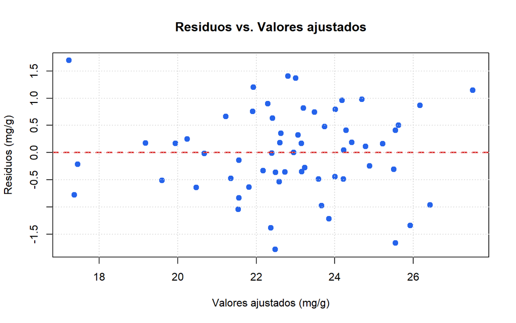

```r
plot(
  residuals(modelo) ~ fitted(modelo),
  pch  = 19,
  col  = "#2563eb",
  cex  = 1.1,
  xlab = "Valores ajustados (mg/g)",
  ylab = "Residuos (mg/g)",
  main = "Residuos vs. Valores ajustados"
)
abline(h = 0, col = "#dc2626", lwd = 2, lty = 2)
grid()
```

> Una nube sin patron alrededor de cero indica que el modelo es adecuado. Un patron sistematico (curva, embudo) sugiere violacion de supuestos.

## 5. Bondad de ajuste: $R^2$ y $R^2$ ajustado

En regresion multiple se usan dos medidas complementarias:

$$R^2 = 1 - \frac{SCR}{SCT}, \qquad
R^2_{adj} = 1 - \frac{SCR/(n-k-1)}{SCT/(n-1)}$$

| Cantidad | Formula | Significado |
| --- | --- | --- |
| $SCT$ | $\sum(y_i - \bar{y})^2$ | Variabilidad total en $Y$ |
| $SCR$ | $\sum(y_i - \hat{y}_i)^2$ | Variabilidad no explicada (residual) |
| $SCE$ | $\sum(\hat{y}_i - \bar{y})^2$ | Variabilidad explicada por el modelo |

> En regresion multiple **siempre** se reporta el $R^2$ ajustado porque el $R^2$ simple aumenta artificialmente al agregar mas predictores, aunque no aporten informacion real.

```r
SCT <- sum((datos$cafeina - mean(datos$cafeina))^2)
SCR <- sum(datos$residuo^2)
SCE <- sum((datos$y_hat - mean(datos$cafeina))^2)
k   <- 5  # numero de coeficientes (3 cuantitativos + 2 dummies de variedad)

cat("SCT =", round(SCT, 2), "\n")
```

```
## SCT = 309.35
```

```r
cat("SCR =", round(SCR, 2), "\n")
```

```
## SCR = 36
```

```r
cat("SCE =", round(SCE, 2), "\n")
```

```
## SCE = 273.35
```

```r
cat("SCE + SCR =", round(SCE + SCR, 2), " (debe coincidir con SCT)\n\n")
```

```
## SCE + SCR = 309.35  (debe coincidir con SCT)
```

```r
R2_manual    <- 1 - SCR / SCT
R2_adj_manual <- 1 - (SCR / (n - k - 1)) / (SCT / (n - 1))
R2_lm        <- summary(modelo)$r.squared
R2_adj_lm    <- summary(modelo)$adj.r.squared

cat("R^2 (manual)      =", round(R2_manual, 4), "\n")
```

```
## R^2 (manual)      = 0.8836
```

```r
cat("R^2 ajustado (manual) =", round(R2_adj_manual, 4), "\n")
```

```
## R^2 ajustado (manual) = 0.8729
```

```r
cat("R^2 (lm)          =", round(R2_lm,     4), "\n")
```

```
## R^2 (lm)          = 0.8836
```

```r
cat("R^2 ajustado (lm) =", round(R2_adj_lm, 4), "\n")
```

```
## R^2 ajustado (lm) = 0.8729
```

```r
cat("\nEl modelo explica el", round(R2_adj_lm * 100, 2),
    "% de la variabilidad del contenido de cafeina (R^2 ajustado).\n")
```

```
##
## El modelo explica el 87.29 % de la variabilidad del contenido de cafeina (R^2 ajustado).
```

> **Alerta:** un $R^2$ alto no garantiza que los supuestos del modelo se cumplan. Siempre debe acompanarse con el diagnostico de residuos.

## 6. Inferencia: prueba F y pruebas t

En regresion multiple la inferencia tiene dos niveles: la prueba **global** (prueba F) y las pruebas **individuales** (pruebas t).

### 6.1 Prueba F global: ¿el modelo sirve?

Evalua si el conjunto de predictores explica algo de la variabilidad de $Y$:

$$H_0: \beta_1 = \beta_2 = \cdots =
\beta_k = 0 \quad \text{vs} \quad H_1: \text{al menos un } \beta_i \neq
0$$

$$F = \frac{SCE / k}{SCR / (n - k -
1)}$$

Se rechaza $H_0$ cuando el valor $p < 0.05$: el modelo en conjunto explica significativamente la variabilidad de $Y$.

```r
resumen <- summary(modelo)
F_stat  <- resumen$fstatistic
F_valor <- F_stat[1]
F_df1   <- F_stat[2]
F_df2   <- F_stat[3]
F_pval  <- pf(F_valor, F_df1, F_df2, lower.tail = FALSE)

cat("Estadistico F =", round(F_valor, 4), "\n")
```

```
## Estadistico F = 82.0101
```

```r
cat("Grados de libertad:", F_df1, "y", F_df2, "\n")
```

```
## Grados de libertad: 5 y 54
```

```r
cat("Valor p          =", format(F_pval, scientific = TRUE, digits = 4), "\n")
```

```
## Valor p          = 5.658e-24
```

```r
cat(ifelse(F_pval < 0.05,
    "Se rechaza H0: el modelo en conjunto es significativo.",
    "No se rechaza H0: el modelo no explica la variabilidad de Y."), "\n")
```

```
## Se rechaza H0: el modelo en conjunto es significativo.
```

> **Importante:** rechazar $H_0$ en la prueba F solo indica que al menos un predictor es util. Para saber cuales, se necesitan las pruebas t individuales.

### 6.2 Pruebas t individuales: ¿cuales predictores importan?

Para cada coeficiente $\beta_i$:

$$H_0: \beta_i = 0 \quad \text{vs} \quad
H_1: \beta_i \neq 0$$

$$t_i =
\frac{\hat{\beta}_i}{\text{EE}(\hat{\beta}_i)}$$

Se rechaza $H_0$ cuando el valor $p < 0.05$: el predictor $X_i$ aporta significativamente al modelo, manteniendo los demas predictores constantes.

```r
tabla_coef <- as.data.frame(summary(modelo)$coefficients)
names(tabla_coef) <- c("Estimado", "Error_std", "t_valor", "p_valor")
tabla_coef        <- round(tabla_coef, 6)
tabla_coef$Decision <- ifelse(tabla_coef$p_valor < 0.05, "Rechazar H0", "No rechazar H0")
mostrar_tabla(tabla_coef, caption = "Pruebas t individuales sobre los coeficientes")
```

Pruebas t individuales sobre los coeficientes

|  | Estimado | Error_std | t_valor | p_valor | Decision |
| --- | --- | --- | --- | --- | --- |
| (Intercept) | 13.572470 | 1.102915 | 12.305994 | 0.0e+00 | Rechazar H0 |
| fertilizante | 0.024421 | 0.001655 | 14.758849 | 0.0e+00 | Rechazar H0 |
| altitud | -0.002251 | 0.000525 | -4.291470 | 7.4e-05 | Rechazar H0 |
| densidad | 0.001029 | 0.000101 | 10.221445 | 0.0e+00 | Rechazar H0 |
| variedadCenicafe1 | 1.955826 | 0.283382 | 6.901734 | 0.0e+00 | Rechazar H0 |
| variedadColombia | 2.177995 | 0.261173 | 8.339267 | 0.0e+00 | Rechazar H0 |

### 6.3 Intervalos de confianza para los coeficientes

```r
ic <- confint(modelo, level = 0.95)
mostrar_tabla(round(as.data.frame(ic), 4),
              caption = "Intervalos de confianza al 95% para los coeficientes")
```

Intervalos de confianza al 95% para los coeficientes

|  | 2.5 % | 97.5 % |
| --- | --- | --- |
| (Intercept) | 11.3613 | 15.7837 |
| fertilizante | 0.0211 | 0.0277 |
| altitud | -0.0033 | -0.0012 |
| densidad | 0.0008 | 0.0012 |
| variedadCenicafe1 | 1.3877 | 2.5240 |
| variedadColombia | 1.6544 | 2.7016 |

> Un IC del 95% para $\beta_i$ que **no contenga el cero** confirma que ese predictor es estadisticamente significativo. Si el intervalo contiene el cero, el predictor podria no aportar al modelo.

## 7. Visualizacion del ajuste: predichos vs. observados

En regresion multiple no hay una recta simple en el plano. La forma mas directa de visualizar el ajuste es graficar los valores predichos contra los valores observados: si el modelo ajusta bien, los puntos deben seguir la diagonal.

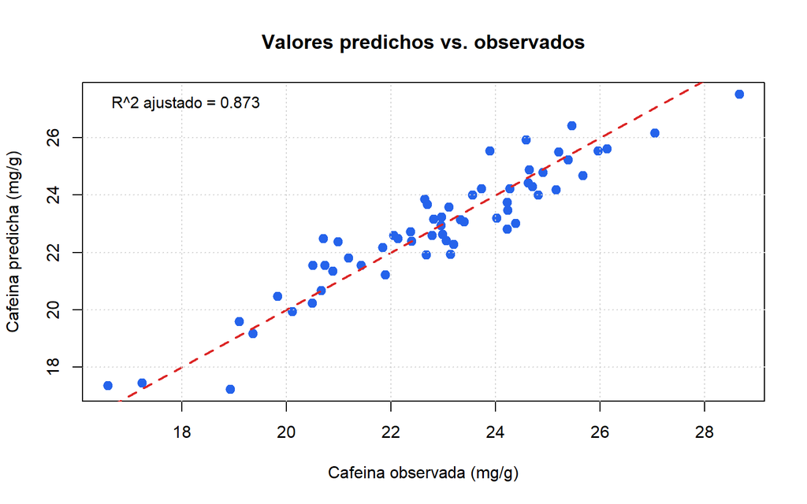

```r
r2_adj <- summary(modelo)$adj.r.squared

plot(
  datos$y_hat ~ datos$cafeina,
  pch  = 19,
  col  = "#2563eb",
  cex  = 1.2,
  xlab = "Cafeina observada (mg/g)",
  ylab = "Cafeina predicha (mg/g)",
  main = "Valores predichos vs. observados"
)
abline(a = 0, b = 1, col = "#dc2626", lwd = 2, lty = 2)
grid()
legend(
  "topleft",
  legend = paste0("R^2 ajustado = ", round(r2_adj, 3)),
  bty = "n", cex = 0.95
)
```

> Los puntos deben distribuirse alrededor de la linea roja (diagonal de 45 grados). Desviaciones sistematicas indican que el modelo no captura bien alguna parte de la variabilidad.

## 8. Diagnostico de supuestos

Para que las pruebas F, t e intervalos de confianza sean validos, el modelo debe satisfacer:

| Supuesto | Descripcion | Herramienta grafica | Prueba estadistica |
| --- | --- | --- | --- |
| Linealidad | $E(Y\|\mathbf{X}) = \mathbf{X}\boldsymbol{\beta}$ | Residuos vs Ajustados | — |
| Independencia | Los $e_i$ son independientes | — | Durbin-Watson |
| Homocedasticidad | $\text{Var}(e_i) = \sigma^2$ constante | Scale-Location | Breusch-Pagan |
| Normalidad | $e_i \sim N(0, \sigma^2)$ | Q-Q plot | Shapiro-Wilk |

### 8.1 Graficos de diagnostico

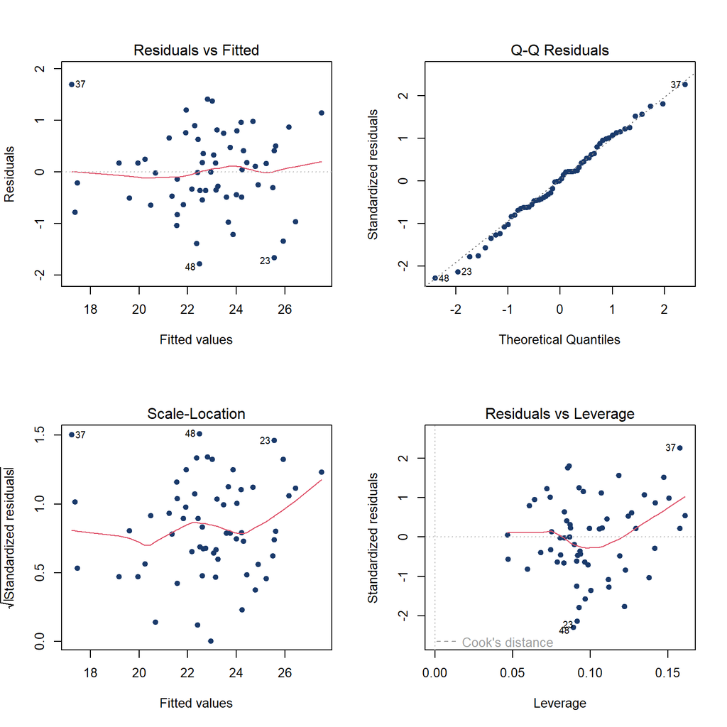

```r
par(mfrow = c(2, 2))
plot(modelo, col = "#1a3a6b", pch = 19, cex = 0.9)
```

```r
par(mfrow = c(1, 1))
```

> En regresion multiple los graficos de diagnostico se interpretan igual que en regresion simple. La diferencia es que los residuos se calculan respecto al hiperplano ajustado, no a una recta.
- **Residuals vs Fitted:** puntos distribuidos aleatoriamente alrededor de cero indican linealidad y homocedasticidad.
- **Normal Q-Q:** los puntos deben seguir la diagonal. Desviaciones indican falta de normalidad.
- **Scale-Location:** la dispersion debe mantenerse constante a lo largo de los valores ajustados.
- **Residuals vs Leverage:** identifica observaciones influyentes mediante la distancia de Cook.

### 8.2 Prueba de Shapiro-Wilk (normalidad)

La prueba contrasta:

$$H_0: \text{los residuos provienen de una
distribucion normal} \quad \text{vs} \quad H_1: \text{no provienen de
una distribucion normal}$$

```r
sw <- shapiro.test(residuals(modelo))
cat("Estadistico W =", round(sw$statistic, 4), "\n")
```

```
## Estadistico W = 0.9914
```

```r
cat("Valor p       =", round(sw$p.value,   4), "\n")
```

```
## Valor p       = 0.9492
```

```r
cat(ifelse(sw$p.value > 0.05,
    "No se rechaza H0: los residuos son compatibles con normalidad.",
    "Se rechaza H0: los residuos no siguen una distribucion normal."), "\n")
```

```
## No se rechaza H0: los residuos son compatibles con normalidad.
```

> **Interpretacion:** el valor $p > 0.05$, por lo tanto **no se rechaza $H_0$**. Los residuos siguen una distribucion aproximadamente normal. El supuesto de normalidad **se cumple**.

### 8.3 Prueba de Breusch-Pagan (homocedasticidad)

La prueba contrasta:

$$H_0: \text{la varianza de los errores es
constante} \quad \text{vs} \quad H_1: \text{la varianza no es constante
(heterocedasticidad)}$$

```r
library(lmtest)
bp <- bptest(modelo)
print(bp)
```

```
##
##  studentized Breusch-Pagan test
##
## data:  modelo
## BP = 8.3732, df = 5, p-value = 0.1368
```

```r
cat(ifelse(bp$p.value > 0.05,
    "No se rechaza H0: varianza constante (homocedasticidad).",
    "Se rechaza H0: hay evidencia de heterocedasticidad."), "\n")
```

```
## No se rechaza H0: varianza constante (homocedasticidad).
```

> **Interpretacion:** el valor $p > 0.05$, por lo tanto **no se rechaza $H_0$**. La varianza de los errores es constante a lo largo de los valores de $X$. El supuesto de homocedasticidad **se cumple**.

### 8.4 Prueba de Durbin-Watson (independencia)

La prueba contrasta:

$$H_0: \text{los residuos son
independientes} \quad \text{vs} \quad H_1: \text{hay autocorrelacion en
los residuos}$$

El estadistico $DW$ toma valores entre 0 y 4; valores cercanos a 2 indican independencia.

```r
dw <- dwtest(modelo)
print(dw)
```

```
##
##  Durbin-Watson test
##
## data:  modelo
## DW = 2.5373, p-value = 0.9821
## alternative hypothesis: true autocorrelation is greater than 0
```

```r
cat(ifelse(dw$p.value > 0.05,
    "No se rechaza H0: los residuos son independientes.",
    "Se rechaza H0: hay autocorrelacion en los residuos."), "\n")
```

```
## No se rechaza H0: los residuos son independientes.
```

> **Interpretacion:** el valor $p > 0.05$, por lo tanto **no se rechaza $H_0$**. Los residuos son independientes entre si. El supuesto de independencia **se cumple**.

### 8.5 Histograma y Q-Q plot de residuos

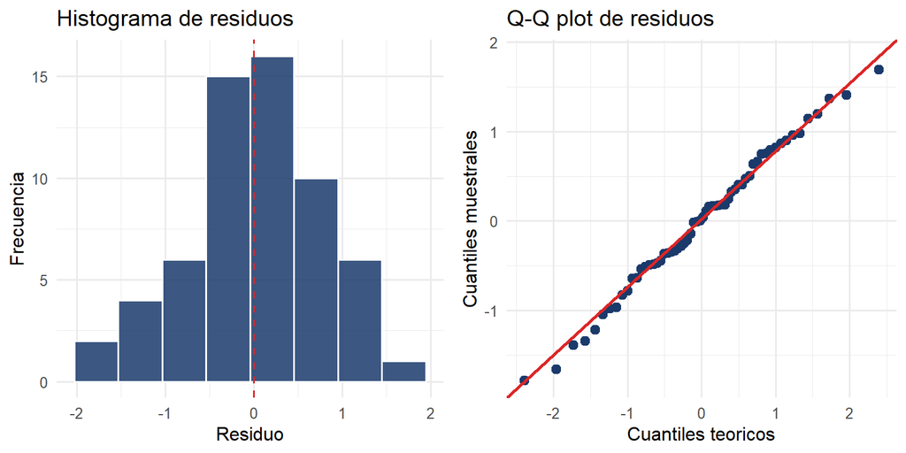

```r
library(ggplot2)

df_res <- data.frame(residuos = residuals(modelo))

p1 <- ggplot(df_res, aes(x = residuos)) +
  geom_histogram(bins = 8, fill = "#1a3a6b", color = "white", alpha = 0.85) +
  geom_vline(xintercept = 0, color = "#dc2626", linetype = "dashed") +
  labs(title = "Histograma de residuos", x = "Residuo", y = "Frecuencia") +
  theme_minimal(base_size = 12)

p2 <- ggplot(df_res, aes(sample = residuos)) +
  stat_qq(color = "#1a3a6b", size = 2.5) +
  stat_qq_line(color = "#dc2626", linewidth = 0.9) +
  labs(title = "Q-Q plot de residuos",
       x = "Cuantiles teoricos", y = "Cuantiles muestrales") +
  theme_minimal(base_size = 12)

gridExtra::grid.arrange(p1, p2, ncol = 2)
```

## 9. Multicolinealidad: deteccion con VIF

La **multicolinealidad** ocurre cuando dos o mas predictores estan altamente correlacionados entre si. Sus consecuencias son: errores estandar inflados, pruebas t poco potentes y coeficientes inestables. Se detecta con el **Factor de Inflacion de la Varianza (VIF)**:

$$\text{VIF}_i = \frac{1}{1 -
R^2_i}$$

donde $R^2_i$ es el $R^2$ de la regresion de $X_i$ sobre los demas predictores.

| Valor VIF | Interpretacion |
| --- | --- |
| $\approx 1$ | Sin correlacion con otros predictores |
| $> 5$ | Multicolinealidad moderada: revisar |
| $> 10$ | Multicolinealidad grave: actuar |

Cuando el modelo incluye variables cualitativas, `car::vif()` reporta una medida generalizada. Para seguir la interpretacion estandar del VIF, se extrae el valor correspondiente a las variables cuantitativas (equivalente al VIF usual) y se omite el factor `variedad` de esta tabla.

```r
library(car)
vif_vals <- vif(modelo)

vif_df <- as.data.frame(vif_vals)
vif_df$Variable <- rownames(vif_df)
vif_df <- vif_df[vif_df$Df == 1, c("Variable", "GVIF")]
names(vif_df)[2] <- "VIF"
vif_df$VIF <- round(vif_df$VIF, 4)

mostrar_tabla(vif_df,
              caption = "VIF por predictor (variables cuantitativas)")
```

VIF por predictor (variables cuantitativas)

|  | Variable | VIF |
| --- | --- | --- |
| fertilizante | fertilizante | 1.0584 |
| altitud | altitud | 1.0106 |
| densidad | densidad | 1.0552 |

> **Interpretacion:** valores VIF menores a 5 indican ausencia de multicolinealidad problematica. Si alguno superara ese umbral, se recomendaria revisar la correlacion entre predictores.

## 10. Prediccion con `predict()`

Una vez validado el modelo puede usarse para predecir $Y$ para nuevas combinaciones de valores de los predictores.

### 10.1 Prediccion puntual

```r
nuevos <- data.frame(
  fertilizante = c(100, 150, 200, 250),
  altitud      = c(1400, 1500, 1600, 1700),
  densidad     = c(5000, 5500, 6000, 6500),
  variedad     = factor(c("Castillo", "Colombia", "Cenicafe1", "Castillo"),
                        levels = levels(datos$variedad))
)
pred <- predict(modelo, newdata = nuevos)

resultado <- cbind(nuevos, cafeina_predicha = round(pred, 2))
mostrar_tabla(resultado, caption = "Predicciones puntuales del contenido de cafeina (mg/g)")
```

Predicciones puntuales del contenido de cafeina (mg/g)

| fertilizante | altitud | densidad | variedad | cafeina_predicha |
| --- | --- | --- | --- | --- |
| 100 | 1400 | 5000 | Castillo | 18.01 |
| 150 | 1500 | 5500 | Colombia | 21.69 |
| 200 | 1600 | 6000 | Cenicafe1 | 22.98 |
| 250 | 1700 | 6500 | Castillo | 22.54 |

### 10.2 Intervalo de confianza vs intervalo de prediccion

Igual que en regresion simple, existen dos tipos de intervalos:

**Intervalo de confianza (IC) para la media:**

$$\hat{y} \pm t_{\alpha/2,\, n-k-1} \cdot
SE(\bar{y}|\mathbf{x}^*)$$

Estima el rango donde se encuentra el **valor promedio** de $Y$ para una combinacion de predictores dada.

**Intervalo de prediccion (IP) para una observacion individual:**

$$\hat{y} \pm t_{\alpha/2,\, n-k-1} \cdot
SE(y_\text{nuevo}|\mathbf{x}^*)$$

Estima el rango donde caera **una nueva observacion individual**. Siempre es mas ancho que el IC.

```r
ic <- predict(modelo, newdata = nuevos, interval = "confidence", level = 0.95)
ip <- predict(modelo, newdata = nuevos, interval = "prediction",  level = 0.95)

tabla_pred <- data.frame(
  Fertilizante = nuevos$fertilizante,
  Altitud      = nuevos$altitud,
  Densidad     = nuevos$densidad,
  Variedad     = nuevos$variedad,
  Prediccion   = round(ic[, "fit"], 1),
  IC_inf       = round(ic[, "lwr"], 1),
  IC_sup       = round(ic[, "upr"], 1),
  IP_inf       = round(ip[, "lwr"], 1),
  IP_sup       = round(ip[, "upr"], 1)
)
mostrar_tabla(tabla_pred,
              caption = "IC para la media e IP para observacion individual al 95%")
```

IC para la media e IP para observacion individual al 95%

| Fertilizante | Altitud | Densidad | Variedad | Prediccion | IC_inf | IC_sup | IP_inf | IP_sup |
| --- | --- | --- | --- | --- | --- | --- | --- | --- |
| 100 | 1400 | 5000 | Castillo | 18.0 | 17.4 | 18.6 | 16.3 | 19.7 |
| 150 | 1500 | 5500 | Colombia | 21.7 | 21.3 | 22.1 | 20.0 | 23.4 |
| 200 | 1600 | 6000 | Cenicafe1 | 23.0 | 22.6 | 23.4 | 21.3 | 24.7 |
| 250 | 1700 | 6500 | Castillo | 22.5 | 22.1 | 23.0 | 20.8 | 24.2 |

> El IP es mas ancho que el IC porque predecir una observacion individual es mas incierto que predecir un promedio.

## 11. Seleccion de variables con criterio AIC

No siempre todos los predictores disponibles deben entrar al modelo. La funcion `step()` aplica seleccion **stepwise** automatica usando el criterio AIC: en cada paso agrega o elimina el predictor que mas mejora el modelo, hasta que ningun cambio reduce el AIC.

```r
modelo_completo <- lm(cafeina ~ fertilizante + altitud + densidad + variedad, data = datos)
modelo_step     <- step(modelo_completo, direction = "both", trace = TRUE)
```

```
## Start:  AIC=-18.65
## cafeina ~ fertilizante + altitud + densidad + variedad
##
##                Df Sum of Sq     RSS     AIC
## <none>                       35.998 -18.652
## - altitud       1    12.277  48.276  -3.045
## - variedad      2    52.107  88.105  31.051
## - densidad      1    69.649 105.647  43.945
## - fertilizante  1   145.209 181.207  76.318
```

```r
cat("\nModelo seleccionado por AIC:\n")
```

```
##
## Modelo seleccionado por AIC:
```

```r
summary(modelo_step)
```

```
##
## Call:
## lm(formula = cafeina ~ fertilizante + altitud + densidad + variedad,
##     data = datos)
##
## Residuals:
##      Min       1Q   Median       3Q      Max
## -1.78242 -0.48850  0.02108  0.53706  1.69421
##
## Coefficients:
##                     Estimate Std. Error t value Pr(>|t|)
## (Intercept)       13.5724700  1.1029154  12.306  < 2e-16 ***
## fertilizante       0.0244210  0.0016547  14.759  < 2e-16 ***
## altitud           -0.0022513  0.0005246  -4.291 7.41e-05 ***
## densidad           0.0010286  0.0001006  10.221 3.13e-14 ***
## variedadCenicafe1  1.9558262  0.2833819   6.902 5.95e-09 ***
## variedadColombia   2.1779953  0.2611735   8.339 2.81e-11 ***
## ---
## Signif. codes:  0 '***' 0.001 '**' 0.01 '*' 0.05 '.' 0.1 ' ' 1
##
## Residual standard error: 0.8165 on 54 degrees of freedom
## Multiple R-squared:  0.8836, Adjusted R-squared:  0.8729
## F-statistic: 82.01 on 5 and 54 DF,  p-value: < 2.2e-16
```

> Si el modelo stepwise coincide con el modelo completo, todos los predictores son utiles. Si elimina alguno, ese predictor no mejoraba el criterio AIC y puede prescindirse de el.

## 12. Resumen del flujo de trabajo en R

```r
#--- 1. Generar / cargar los datos ---
set.seed(42)
datos <- data.frame(cafeina, fertilizante, altitud, densidad, variedad)

#--- 2. Exploracion ---
summary(datos)
cor(datos[, sapply(datos, is.numeric)])  # solo variables numericas
table(datos$variedad)                    # frecuencias de la variable cualitativa
boxplot(cafeina ~ variedad, data = datos)
pairs(datos[, sapply(datos, is.numeric)])

#--- 3. Ajuste del modelo ---
modelo <- lm(cafeina ~ fertilizante + altitud + densidad + variedad, data = datos)
summary(modelo)
confint(modelo)

#--- 4. Bondad de ajuste ---
# R^2 y R^2 ajustado en summary(modelo)
# Prueba F global en summary(modelo)

#--- 5. Multicolinealidad ---
library(car)
vif(modelo)

#--- 6. Diagnostico de supuestos ---
par(mfrow = c(2, 2))
plot(modelo)

shapiro.test(residuals(modelo))   # Normalidad
library(lmtest)
bptest(modelo)                    # Homocedasticidad
dwtest(modelo)                    # Independencia

#--- 7. Seleccion de variables ---
modelo_step <- step(modelo, direction = "both")

#--- 8. Prediccion ---
nuevos <- data.frame(fertilizante = 150, altitud = 1500, densidad = 5500)
predict(modelo, newdata = nuevos)
predict(modelo, newdata = nuevos, interval = "confidence")
predict(modelo, newdata = nuevos, interval = "prediction")
```

# Parte II: Trabajo para Entregar

## Instrucciones generales

El trabajo debe presentarse en formato de **articulo cientifico** con las siguientes secciones obligatorias: portada, introduccion, metodologia, desarrollo, conclusiones y bibliografia. Puede elaborarse en **Word, Google Docs, R Markdown o cualquier procesador de texto** de su preferencia, y debe entregarse en formato **PDF**.

El enfoque del trabajo es el **analisis e interpretacion de resultados**: cada salida de R debe ir acompanada de su correspondiente interpretacion en el contexto del problema. No basta con pegar el output; se debe explicar que significa.

**Fecha de entrega:** segun lo indicado por el docente.  
**Trabajo individual.**

## Contexto del problema

Un grupo de investigadores del Centro Internacional de Agricultura Tropical (CIAT) quiere identificar que factores agronomicos y ambientales determinan el **contenido de proteina del grano de frijol** (variable $Y$, en %) en parcelas experimentales del departamento de Nariño. Para ello se registraron datos de **50 parcelas** con las siguientes variables:

| Columna | Tipo | Descripcion | Unidad / Categorias |
| --- | --- | --- | --- |
| `proteina` | Cuantitativa | Contenido de proteina del grano de frijol | % |
| `nitrogeno` | Cuantitativa | Dosis de nitrogeno aplicada | kg N/ha |
| `precipitacion` | Cuantitativa | Precipitacion acumulada durante el ciclo | mm |
| `temperatura` | Cuantitativa | Temperatura media diaria durante el ciclo | °C |
| `materia_org` | Cuantitativa | Contenido de materia organica del suelo | % |
| `sistema` | Cualitativa | Sistema de siembra utilizado | Tradicional / Asociado / Tecnificado |

Los datos se generan con el siguiente codigo, que debe ejecutarse **una sola vez** para crear el archivo `datos_frijol.csv` en su directorio de trabajo. Luego puede cargarlo normalmente con `read.csv()`.

```r
set.seed(321)
m             <- 50
nitrogeno     <- round(runif(m, 40, 160), 1)
precipitacion <- round(runif(m, 350, 750), 0)
temperatura   <- round(runif(m, 14, 22), 1)
materia_org   <- round(runif(m, 1.5, 5.5), 2)
sistema       <- factor(sample(c("Tradicional", "Asociado", "Tecnificado"),
                               m, replace = TRUE))
proteina   <- round(
  18 + 0.03 * nitrogeno + 0.01 * precipitacion -
  0.15 * temperatura + 0.8 * materia_org +
  ifelse(sistema == "Asociado",    1.5, 0) +
  ifelse(sistema == "Tecnificado", 3.0, 0) +
  rnorm(m, 0, 1.2), 2
)
datos_frijol <- data.frame(proteina, nitrogeno, precipitacion,
                           temperatura, materia_org, sistema)
write.csv(datos_frijol, "datos_frijol.csv", row.names = FALSE)
```

Una vez creado el archivo, cargue los datos con:

```r
datos <- read.csv("datos_frijol.csv")
```

## Estructura del articulo

### Portada

La portada debe incluir:

- Titulo del trabajo
- Nombre completo del estudiante y codigo
- Nombre del curso y grupo
- Nombre del docente
- Fecha de entrega
- Universidad y facultad

### 1. Introduccion

Redacte un parrafo de introduccion que incluya:

- Importancia del cultivo de frijol en Colombia y en el departamento de Nariño.
- Por que es necesario un modelo de regresion multiple (y no simple) para este problema.
- Objetivo del analisis estadistico.
- Breve descripcion de la metodologia que se usara (regresion lineal multiple por MCO).

### 2. Metodologia

Describa brevemente:

- El modelo estadistico utilizado, incluyendo las variables indicadoras (dummies) para la variable cualitativa `sistema` (con “Tradicional” como categoria de referencia):
  $$Y_i = \beta_0 + \beta_1 X_{1i} + \beta_2 X_{2i} +
  \beta_3 X_{3i} + \beta_4 X_{4i} + \beta_5 D_{\text{Asociado},i} +
  \beta_6 D_{\text{Tecnificado},i} + e_i$$
- El metodo de estimacion (MCO) y su solucion matricial $\hat{\boldsymbol{\beta}} = (\mathbf{X}^\top\mathbf{X})^{-1}\mathbf{X}^\top\mathbf{Y}$.
- Las herramientas de R empleadas.
- Los supuestos del modelo y las pruebas estadisticas usadas para verificarlos.

### 3. Desarrollo

Esta es la seccion principal. Debe incluir codigo R, resultados y su interpretacion para cada uno de los siguientes puntos:

#### 3.1 Carga y exploracion de los datos

Cargue el archivo `datos_frijol.csv`. Presente las estadisticas descriptivas, la matriz de correlaciones de las variables cuantitativas, un diagrama de caja de `proteina` por `sistema`, y los diagramas de dispersion por pares (solo variables cuantitativas).

**Preguntas:**

1. Que predictores cuantitativos tienen la correlacion mas alta con el contenido de proteina? Esto es coherente con lo esperado agronomicamente?
2. Hay algun par de predictores con correlacion mayor a 0.7? Que puede implicar esto para el modelo?
3. El diagrama de caja sugiere que el sistema de siembra afecta el contenido de proteina? Justifique.

#### 3.2 Ajuste del modelo de regresion multiple

Ajuste el modelo completo con los cuatro predictores cuantitativos y la variable cualitativa `sistema` usando `lm()`. Presente el resumen completo del modelo.

**Preguntas:**

1. Escriba la ecuacion del modelo estimado con cuatro decimales para cada coeficiente.
2. Interprete el coeficiente de `nitrogeno` en el contexto del problema.
3. Interprete el coeficiente de `temperatura` en el contexto del problema.
4. Interprete el coeficiente de `sistemaAsociado`. Que significa en terminos del contenido de proteina respecto al sistema Tradicional, manteniendo los demas predictores constantes?
5. Interprete el intercepto $b_0$. Tiene sentido practico en este contexto?

#### 3.3 Bondad de ajuste

Reporte el $R^2$ y el $R^2$ ajustado del modelo completo.

**Preguntas:**

1. Que porcentaje de la variabilidad del contenido de proteina explica el modelo (use el $R^2$ ajustado)?
2. Por que en regresion multiple se prefiere el $R^2$ ajustado sobre el $R^2$ simple?

#### 3.4 Prueba F global e inferencia sobre los coeficientes

Reporte el estadistico F, sus grados de libertad y el valor $p$. Luego presente la tabla de pruebas t individuales y los intervalos de confianza al 95% para cada coeficiente.

**Preguntas:**

1. La prueba F es significativa al nivel del 5%? Que concluye sobre el modelo en conjunto?
2. Cuales predictores son estadisticamente significativos al nivel del 5% segun las pruebas t?
3. El IC al 95% para `precipitacion` contiene el cero? Que implica esto?
4. Los coeficientes de `sistemaAsociado` y `sistemaTecnificado` son significativos? Que indica esto sobre el efecto del sistema de siembra en el contenido de proteina?
5. Hay algun predictor que no sea significativo? Podria eliminarse del modelo?

#### 3.5 Diagnostico de multicolinealidad

Calcule el VIF para los predictores cuantitativos usando `car::vif()`. Para la variable cualitativa `sistema` no se reporta un VIF estandar, asi que omitala de la tabla y revise solo los valores de las variables continuas.

**Preguntas:**

1. Hay evidencia de multicolinealidad segun los valores VIF? Justifique.
2. El VIF maximo supera el umbral de 5? Que indica esto?
3. Si hubiera multicolinealidad entre dos predictores, como afectaria la interpretacion de los coeficientes?

#### 3.6 Validacion de supuestos

Presente los cuatro graficos de diagnostico (`plot(modelo)`) y aplique las tres pruebas estadisticas.

**Preguntas:**

1. **Normalidad:** reporte el estadistico $W$ y el valor $p$ de la prueba de Shapiro-Wilk. Se rechaza $H_0$? El supuesto se cumple?
2. **Homocedasticidad:** reporte el valor $p$ de la prueba de Breusch-Pagan. Se rechaza $H_0$? El supuesto se cumple?
3. **Independencia:** reporte el estadistico $DW$ y el valor $p$. Se rechaza $H_0$? El supuesto se cumple?
4. A partir de los graficos y las pruebas, el modelo es valido para realizar inferencias?

#### 3.7 Seleccion de variables

Aplique seleccion stepwise con `step(modelo, direction = "both")`. Compare el modelo seleccionado con el modelo completo.

**Preguntas:**

1. El modelo stepwise elimino algun predictor? Cual es el modelo final seleccionado?
2. El $R^2$ ajustado del modelo seleccionado es mayor o menor que el del modelo completo? Que implica esto?
3. Segun el criterio AIC, es preferible el modelo completo o el modelo reducido?

#### 3.8 Prediccion

Use `predict()` para predecir el contenido de proteina para las siguientes tres parcelas nuevas:

| Parcela | `nitrogeno` | `precipitacion` | `temperatura` | `materia_org` | `sistema` |
| --- | --- | --- | --- | --- | --- |
| A | 80 | 500 | 16 | 3.5 | Tradicional |
| B | 120 | 650 | 18 | 4.2 | Tecnificado |
| C | 60 | 420 | 20 | 2.8 | Asociado |

Reporte la prediccion puntual, el IC y el IP al 95% para cada caso.

**Preguntas:**

1. Para la parcela B (sistema Tecnificado), cual es el contenido de proteina esperado?
2. Compare la prediccion de la parcela A (Tradicional) con la parcela B (Tecnificado), manteniendo similares los demas valores. A que se debe la diferencia?
3. Por que el intervalo de prediccion es mas ancho que el intervalo de confianza?

### 4. Conclusiones

Redacte un parrafo de conclusiones que sintetice:

- Cuales factores influyen significativamente en el contenido de proteina del frijol.
- La magnitud e interpretacion de los coeficientes significativos.
- El ajuste del modelo ($R^2$ ajustado) y su implicacion practica.
- El cumplimiento de los supuestos y la validez del modelo.
- Una recomendacion practica para los productores de frijol en Nariño basada en los resultados.

### 5. Bibliografia

Toda fuente consultada debe citarse: libros, articulos, paginas web o documentacion de R. Use formato APA.

Ejemplos:

> Montgomery, D. C., Peck, E. A., & Vining, G. G. (2012). *Introduction to Linear Regression Analysis* (5th ed.). Wiley.

> R Core Team (2024). *R: A Language and Environment for Statistical Computing*. R Foundation for Statistical Computing. https://www.R-project.org/

> Nombre del autor o sitio (ano). *Titulo de la pagina o articulo*. Recuperado de: [URL completa]